# Lab 8: Evaluating Conditions & Conducting Hypothesis Tests

# Inference

## Stating the Hypotheses

Now that you’ve decided on what regression appears the most linear, let’s perform a hypothesis test for the slope coefficient.

**7. Write the hypotheses *in words* for testing if there is a linear relationship between the variables you used for your model in #4.**

*Keep in mind, if you log-transformed y, you are testing if there is a linear relationship between log(y) and x!*

$H_0$: there is no linear relationship between log(GDP per Capita) and life expectancy

$H_A$: there is a linear relationship between log(GDP per Capita) and life expectancy

## Obtaining a p-value Using Simulation

Next, we will work through creating a permutation distribution using tools from the **infer** package.

**8. First, we need to find the observed difference slope statistic, which we will save as `obs_slope`.**

*Keep in mind, if you log-transformed y, you need to use log(y) as your repsonse variable!*

```r
obs_slope <-  gapminder %>%
  specify(response = lifeExp, explanatory = log(gdpPercap)) %>%
  calculate(stat = "slope")
```

After you have calculated your observed statistic, you need to create a permutation distribution of statistics that might have occurred if the null hypothesis was true.

```r
# Code for question 7 goes here!

null_dist <- gapminder %>%
  specify(response = lifeExp, explanatory = log(gdpPercap)) %>%
  hypothesise(null = "independence") %>%
  generate(reps = 1000, type = "permute") %>%
  calculate(stat = "slope")
```

We can visualize this null distribution with the following code:

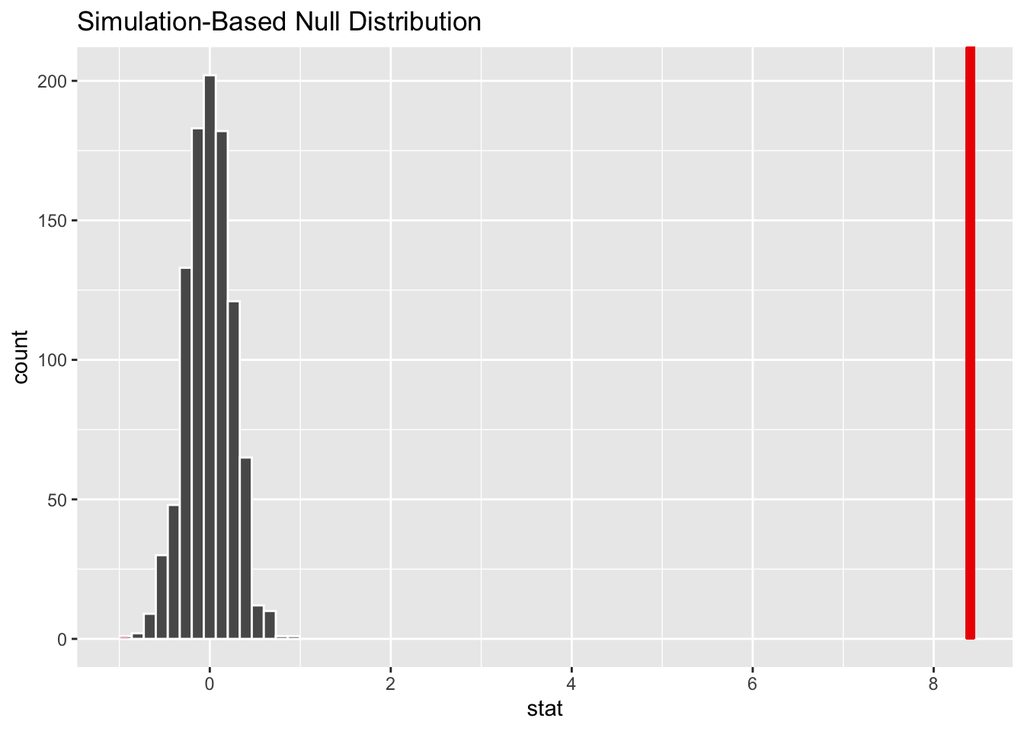

```r
visualise(null_dist)  +
  shade_p_value(obs_stat = obs_slope,
                direction = "two-sided")
```

**10. Use the `shade_p_value()` function to add a vertical red line to the plot above, demonstrating where the observed slope statistic (`obs_slope`) falls on the distribution.**

Now that you have calculated the observed statistic and generated a permutation distribution, you can calculate the p-value for your hypothesis test using the function `get_p_value()` from the infer package.

**11. Fill in the code below to calculate the p-value for the hypothesis test you stated in #4.**

```r
get_p_value(null_dist,
            obs_stat = obs_slope,
            direction = "two-sided")
```

```
# A tibble: 1 × 1
  p_value
    <dbl>
1       0
```

**12. Based on your p-value and an $\alpha = 0.1$, what decision would you reach regarding the hypotheses you stated in #7?**

Reject the null, p-value is less than 0.1.

## Obtaining a p-value Using Theory

As we saw in the reading this week, the output from the `get_regression_table()` function provides us with theory-based estimates of our standard error, $t$-statistic, and p-value.

**Use the `get_regression_table()` function to obtain the theory-based p-value for your hypothesis test.**

*Hint: You’ll want to use the model you fit in #4.*

```r
get_regression_table(gapminder_lm)
```

```
# A tibble: 2 × 7
  term           estimate std_error statistic p_value lower_ci upper_ci
  <chr>             <dbl>     <dbl>     <dbl>   <dbl>    <dbl>    <dbl>
1 intercept         -9.10     1.23      -7.41       0   -11.5     -6.69
2 log(gdpPercap)     8.40     0.149     56.5        0     8.11     8.70
```

**13. How does this p-value compare to what you obtained in #11?**

Pretty much the same, practically 0.

**14. Why do you believe these p-values were similar or different?**

**15. Based on your answers to #4-6, which p-value do you believe is the most reliable? Why?**